# County-Level Grocery Price Trend: Statistical Power Analysis

Grocery Pricing Project

March 23, 2026

# 1 Overview

This report answers a simple question: **when we receive county-level NielsenIQ Homescan receipt data, which product categories will have enough observations to support reliable trend analysis of price per unit?**

The approach:

- For each product category, compute the **minimum detectable annual price trend (MDE)** at 80% power, as a function of the number of purchase transactions observed per county per week.
- Express results as the **minimum viable weekly n** – the transaction count a county-category cell needs to detect a 2%, 5%, or 10% annual price trend.
- Validate the analytical formula against simulation.

## 1.1 Key assumptions

| Assumption | Value | Notes |
| --- | --- | --- |
| Estimand | Annual % change in log(price per unit) | Scale-free; directly interpretable |
| Model | `log(p) ~ week + month_dummies` | OLS with 11 seasonal controls |
| Inference | Sandwich (Newey-West) standard errors | Robust to AR(1) autocorrelation |
| Power target | 80%, two-sided alpha = 0.05 | Standard |
| Autocorrelation | Sweep rho = 0, 0.3, 0.5, 0.7 | Weekly shelf prices are sticky |
| Transaction-level SD | 0.15 / 0.30 / 0.50 | Standardised index / typical / raw mean |
| Time spans | 104, 156, 208, 260 weeks (2-5 years) |  |

# 2 Data: NielsenIQ product hierarchy

The Homescan Disagg Hierarchy contains **774 product categories** across **78 supercategories**. Of these, **20 supercategories** have been selected based on the NHANES meal-archetype analysis (a coverage-maximising 20-category pick designed to reconstruct as many meal patterns as possible from Homescan purchase data). These cover **381 categories** and **19,675,189 national purchase occasions** in the latest 52-week period.

NHANES-recommended 20 supercategories, sorted by total national occasions

| Supercategory | Categories | National Occ. | Min Cat Occ. | Median Cat Occ. |
| --- | --- | --- | --- | --- |
| VEGETABLES | 35 | 2,902,951 | 669 | 28,251.0 |
| BEVERAGES | 18 | 2,586,912 | 15 | 57,794.5 |
| PREPARED FOODS | 36 | 2,030,893 | 3 | 20,664.5 |
| FRUIT | 50 | 1,631,468 | 66 | 13,035.0 |
| SALTY SNACKS | 18 | 1,604,153 | 143 | 36,084.5 |
| CHEESE | 58 | 1,569,344 | 2 | 2,223.5 |
| DESSERTS/SWEET GOODS | 49 | 1,089,519 | 1 | 1,857.0 |
| MILK PRODUCTS | 7 | 943,837 | 629 | 15,546.0 |
| COOKIES & CRACKERS | 4 | 930,529 | 167 | 210,695.5 |
| BREAD | 14 | 801,129 | 2 | 6,505.5 |
| COFFEE | 2 | 567,166 | 264,274 | 283,583.0 |
| PASTA/RICE/GRAINS | 7 | 494,089 | 83 | 29,481.0 |
| CEREAL & GRANOLA | 5 | 493,619 | 395 | 13,223.0 |
| EGGS | 4 | 488,676 | 113 | 8,138.0 |
| CONDIMENTS | 15 | 415,091 | 169 | 19,368.0 |
| SEAFOOD | 29 | 338,964 | 15 | 2,020.0 |
| WRAPS & TORTILLA SHELLS | 10 | 231,567 | 2 | 1,203.5 |
| NUT BUTTERS/JAM/JELLIES | 14 | 226,116 | 3 | 564.5 |
| PIZZA | 3 | 223,056 | 1,232 | 8,550.0 |
| MEAL COMBOS | 3 | 106,110 | 17,814 | 37,888.0 |

The distribution of national occasions is extremely right-skewed: the median category has about 6,650 occasions nationally, but the 10th percentile is only 75. Once spread across 1,000+ counties, many cells will be thin.

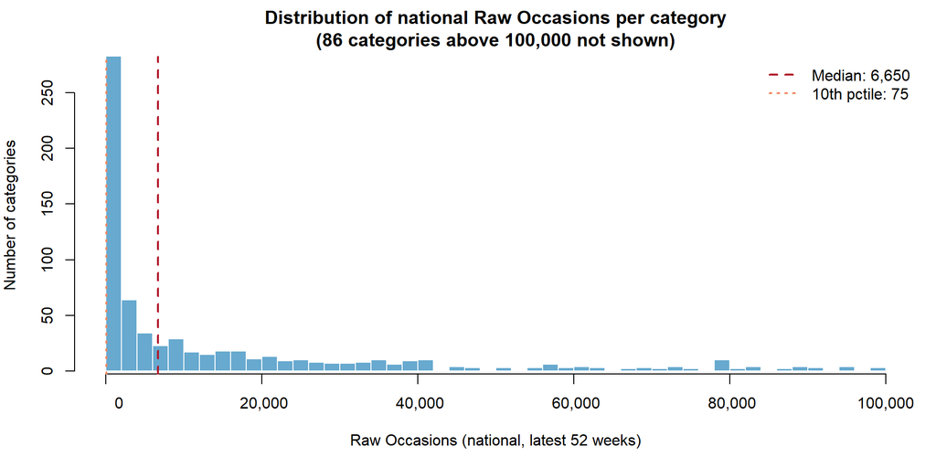

# 3 Key findings

> **Supercategory-level analysis is viable in most counties.** At the supercategory level (e.g. all of VEGETABLES, all of CHEESE), the 20 NHANES-recommended picks have enough volume for county-level price-trend detection in large and mid-size counties with 5 years of data.

> **Category-level analysis is not.** When you drill down to individual categories (e.g. *Tomatoes*, *Cheddar*, *Potato Chip*), the picture is far more sobering:
> - **223 of 381 categories (59%) are infeasible even in large metro counties** – too few transactions for a single nonzero week.
> - **315 of 381 (83%) are infeasible in mid-size counties.**
> - **371 of 381 (97%) are infeasible in small/rural counties.**

> Only the highest-volume categories (SOFT DRINKS, COWS MILK, BREAD, CHICKEN EGGS, POTATOES, POTATO CHIP, and roughly 50–80 others) can support category-level county trend analysis. For everything else, you must work at the supercategory aggregate or use pooled/hierarchical models.

# 4 Method

## 4.1 The MDE formula

We model weekly county-category log mean price as:

$$\log(p_w) = \alpha + \beta \cdot w +
\sum_{m=2}^{12} \gamma_m \cdot \mathbf{1}[\text{month}=m] +
\varepsilon_w$$

where $\varepsilon_w$ follows an AR(1) process with persistence $\rho$.

The OLS slope estimator $\hat\beta$ has true variance under AR(1) errors:

$$\text{Var}(\hat\beta) = \sigma_w^2 \cdot
\left[ (X'X)^{-1} X' \Omega X (X'X)^{-1}
\right]_{2,2}$$

where $\Omega_{ij} = \rho^{|i-j|}$ is the AR(1) correlation matrix, and $\sigma_w^2 = \sigma_{\text{txn}}^2 / n + \sigma_{\text{week}}^2$ is the variance of the weekly log mean price (combining transaction-level variance averaged down by $n$ transactions, plus irreducible week-level variance).

The **sandwich form** is computed numerically for each $(T, \rho)$ combination – this is exact, unlike the commonly used `sqrt((1+rho)/(1-rho))` approximation which applies only to sample means, not regression slopes with covariates.

The MDE (annualised) is then:

$$\text{MDE}_{\text{annual}} = 52 \times
(t_{\alpha/2, df} + t_{\text{power}, df}) \times
\text{SE}_{\text{sandwich}}(\hat\beta)$$

converted from log-points to percentage via $100 \times (e^{\text{MDE}} - 1)$.

## 4.2 Feasibility filter

Before computing MDEs, we check whether a county-category cell has enough nonzero weeks. Under a Poisson arrival model, the expected fraction of nonzero weeks is $1 - e^{-n}$ where $n$ is the expected weekly transaction count. We require at least 77% of weeks to have $\geq 1$ transaction (annualised: 40 out of 52 weeks), implying a minimum expected $n \approx 1.6$ per week.

# 5 Results

## 5.1 Five years of data substantially improves power

With 5 years (260 weeks) of receipt data, the model has 247 residual degrees of freedom after fitting the intercept, trend, and 11 month dummies. This is a large improvement over 2 years (91 df) – more weeks means both more precise slope estimates and better-behaved t-statistics. The tables below show how minimum-n requirements drop as the time span increases from 2 to 5 years.

## 5.2 Minimum viable weekly n

The tables below show the minimum average weekly transaction count needed per county-category cell to detect a given annual price trend, at 80% power. All use $\sigma_{\text{week}} = 0.01$ (conservative).

### 5.2.1 Standardised price index ($\sigma_{\text{txn}} = 0.15$)

A standardised index normalises for package size and brand mix – the cleanest measure of actual price movement.

Minimum weekly n: standardised price index (sigma_txn = 0.15)

| Time span | Autocorrelation (rho) | MDE < 2%/yr | MDE < 5%/yr | MDE < 10%/yr |
| --- | --- | --- | --- | --- |
| 104 wks (2 yr) | 0.0 | 25 | 5 | 2 |
| 104 wks (2 yr) | 0.3 | 50 | 10 | 2 |
| 104 wks (2 yr) | 0.5 | 100 | 10 | 5 |
| 104 wks (2 yr) | 0.7 | 250 | 25 | 5 |
| 156 wks (3 yr) | 0.0 | 5 | 2 | 2 |
| 156 wks (3 yr) | 0.3 | 10 | 2 | 2 |
| 156 wks (3 yr) | 0.5 | 25 | 5 | 2 |
| 156 wks (3 yr) | 0.7 | 50 | 5 | 2 |
| 208 wks (4 yr) | 0.0 | 2 | 2 | 2 |
| 208 wks (4 yr) | 0.3 | 5 | 2 | 2 |
| 208 wks (4 yr) | 0.5 | 10 | 2 | 2 |
| 208 wks (4 yr) | 0.7 | 10 | 2 | 2 |
| 260 wks (5 yr) | 0.0 | 2 | 2 | 2 |
| 260 wks (5 yr) | 0.3 | 2 | 2 | 2 |
| 260 wks (5 yr) | 0.5 | 5 | 2 | 2 |
| 260 wks (5 yr) | 0.7 | 5 | 2 | 2 |

### 5.2.2 Typical category ($\sigma_{\text{txn}} = 0.30$)

Representative of a reasonably well-defined product category or a decent price index with some residual mix noise.

Minimum weekly n: typical category (sigma_txn = 0.30)

| Time span | Autocorrelation (rho) | MDE < 2%/yr | MDE < 5%/yr | MDE < 10%/yr |
| --- | --- | --- | --- | --- |
| 104 wks (2 yr) | 0.0 | 100 | 25 | 5 |
| 104 wks (2 yr) | 0.3 | 250 | 25 | 10 |
| 104 wks (2 yr) | 0.5 | 500 | 50 | 10 |
| 104 wks (2 yr) | 0.7 | > 500 | 100 | 25 |
| 156 wks (3 yr) | 0.0 | 25 | 5 | 2 |
| 156 wks (3 yr) | 0.3 | 50 | 10 | 2 |
| 156 wks (3 yr) | 0.5 | 100 | 10 | 5 |
| 156 wks (3 yr) | 0.7 | 250 | 25 | 5 |
| 208 wks (4 yr) | 0.0 | 10 | 2 | 2 |
| 208 wks (4 yr) | 0.3 | 25 | 5 | 2 |
| 208 wks (4 yr) | 0.5 | 25 | 5 | 2 |
| 208 wks (4 yr) | 0.7 | 50 | 10 | 2 |
| 260 wks (5 yr) | 0.0 | 5 | 2 | 2 |
| 260 wks (5 yr) | 0.3 | 10 | 2 | 2 |
| 260 wks (5 yr) | 0.5 | 25 | 2 | 2 |
| 260 wks (5 yr) | 0.7 | 25 | 5 | 2 |

### 5.2.3 Raw category mean ($\sigma_{\text{txn}} = 0.50$)

If you use the unweighted average receipt price across all UPCs in a category, package-size and brand mixing inflate variance substantially.

Minimum weekly n: raw category mean (sigma_txn = 0.50)

| Time span | Autocorrelation (rho) | MDE < 2%/yr | MDE < 5%/yr | MDE < 10%/yr |
| --- | --- | --- | --- | --- |
| 104 wks (2 yr) | 0.0 | 250 | 50 | 10 |
| 104 wks (2 yr) | 0.3 | 500 | 100 | 25 |
| 104 wks (2 yr) | 0.5 | > 500 | 100 | 25 |
| 104 wks (2 yr) | 0.7 | > 500 | 250 | 50 |
| 156 wks (3 yr) | 0.0 | 50 | 10 | 5 |
| 156 wks (3 yr) | 0.3 | 100 | 25 | 5 |
| 156 wks (3 yr) | 0.5 | 250 | 25 | 10 |
| 156 wks (3 yr) | 0.7 | 500 | 50 | 25 |
| 208 wks (4 yr) | 0.0 | 25 | 5 | 2 |
| 208 wks (4 yr) | 0.3 | 50 | 10 | 2 |
| 208 wks (4 yr) | 0.5 | 100 | 10 | 5 |
| 208 wks (4 yr) | 0.7 | 250 | 25 | 5 |
| 260 wks (5 yr) | 0.0 | 10 | 2 | 2 |
| 260 wks (5 yr) | 0.3 | 25 | 5 | 2 |
| 260 wks (5 yr) | 0.5 | 50 | 5 | 2 |
| 260 wks (5 yr) | 0.7 | 100 | 10 | 5 |

**Reading these tables:** at the intersection of your time span, autocorrelation assumption, and desired MDE threshold, the number shown is the minimum average weekly transaction count a county-category cell needs. For example, with 5 years of data, moderate autocorrelation ($\rho = 0.5$), and a typical category ($\sigma = 0.30$), look up the row for 260 wks / rho = 0.5 to find the required weekly n for each MDE threshold.

## 5.3 Category feasibility: NHANES-recommended 20

The tables below map these thresholds to the 20 NHANES-recommended supercategories using three illustrative county-size scenarios: **large metro** (0.5% of the national panel), **mid-size** (0.1%), and **small/rural** (0.02%). All assume **5 years of data** (260 weeks) and moderate autocorrelation ($\rho = 0.5$).

### 5.3.1 Standardised index (sigma = 0.15)

Feasibility at rho=0.5, T=260 weeks (5 yr): Standardised index (sigma = 0.15)

| Supercategory | Natl Occasions | Large metro (0.5%) | Mid-size (0.1%) | Small/rural (0.02%) |
| --- | --- | --- | --- | --- |
| VEGETABLES | 2,902,951 | 0.3% well_powered | 0.5% well_powered | 1.0% well_powered |
| BEVERAGES | 2,586,912 | 0.3% well_powered | 0.5% well_powered | 1.0% well_powered |
| PREPARED FOODS | 2,030,893 | 0.3% well_powered | 0.6% well_powered | 1.2% well_powered |
| FRUIT | 1,631,468 | 0.3% well_powered | 0.6% well_powered | 1.3% well_powered |
| SALTY SNACKS | 1,604,153 | 0.3% well_powered | 0.6% well_powered | 1.3% well_powered |
| CHEESE | 1,569,344 | 0.3% well_powered | 0.6% well_powered | 1.3% well_powered |
| DESSERTS/SWEET GOODS | 1,089,519 | 0.4% well_powered | 0.7% well_powered | 1.6% well_powered |
| MILK PRODUCTS | 943,837 | 0.4% well_powered | 0.8% well_powered | 1.7% well_powered |
| COOKIES & CRACKERS | 930,529 | 0.4% well_powered | 0.8% well_powered | 1.7% well_powered |
| BREAD | 801,129 | 0.4% well_powered | 0.8% well_powered | 1.8% well_powered |
| COFFEE | 567,166 | 0.5% well_powered | 1.0% well_powered | 2.2% adequate |
| PASTA/RICE/GRAINS | 494,089 | 0.5% well_powered | 1.1% well_powered | 2.3% adequate |
| CEREAL & GRANOLA | 493,619 | 0.5% well_powered | 1.1% well_powered | 2.3% adequate |
| EGGS | 488,676 | 0.5% well_powered | 1.1% well_powered | 2.4% adequate |
| CONDIMENTS | 415,091 | 0.5% well_powered | 1.2% well_powered | n=1.6 INFEASIBLE |
| SEAFOOD | 338,964 | 0.6% well_powered | 1.3% well_powered | n=1.3 INFEASIBLE |
| WRAPS & TORTILLA SHELLS | 231,567 | 0.7% well_powered | 1.5% well_powered | n=0.9 INFEASIBLE |
| NUT BUTTERS/JAM/JELLIES | 226,116 | 0.7% well_powered | 1.6% well_powered | n=0.9 INFEASIBLE |
| PIZZA | 223,056 | 0.7% well_powered | 1.6% well_powered | n=0.9 INFEASIBLE |
| MEAL COMBOS | 106,110 | 1.0% well_powered | 2.3% adequate | n=0.4 INFEASIBLE |

### 5.3.2 Typical category (sigma = 0.30)

Feasibility at rho=0.5, T=260 weeks (5 yr): Typical category (sigma = 0.30)

| Supercategory | Natl Occasions | Large metro (0.5%) | Mid-size (0.1%) | Small/rural (0.02%) |
| --- | --- | --- | --- | --- |
| VEGETABLES | 2,902,951 | 0.4% well_powered | 0.9% well_powered | 1.9% well_powered |
| BEVERAGES | 2,586,912 | 0.5% well_powered | 0.9% well_powered | 2.0% adequate |
| PREPARED FOODS | 2,030,893 | 0.5% well_powered | 1.0% well_powered | 2.3% adequate |
| FRUIT | 1,631,468 | 0.6% well_powered | 1.2% well_powered | 2.6% adequate |
| SALTY SNACKS | 1,604,153 | 0.6% well_powered | 1.2% well_powered | 2.6% adequate |
| CHEESE | 1,569,344 | 0.6% well_powered | 1.2% well_powered | 2.6% adequate |
| DESSERTS/SWEET GOODS | 1,089,519 | 0.7% well_powered | 1.4% well_powered | 3.2% adequate |
| MILK PRODUCTS | 943,837 | 0.7% well_powered | 1.5% well_powered | 3.4% adequate |
| COOKIES & CRACKERS | 930,529 | 0.7% well_powered | 1.5% well_powered | 3.4% adequate |
| BREAD | 801,129 | 0.8% well_powered | 1.6% well_powered | 3.7% adequate |
| COFFEE | 567,166 | 0.9% well_powered | 2.0% well_powered | 4.4% adequate |
| PASTA/RICE/GRAINS | 494,089 | 1.0% well_powered | 2.1% adequate | 4.7% adequate |
| CEREAL & GRANOLA | 493,619 | 1.0% well_powered | 2.1% adequate | 4.7% adequate |
| EGGS | 488,676 | 1.0% well_powered | 2.1% adequate | 4.8% adequate |
| CONDIMENTS | 415,091 | 1.0% well_powered | 2.3% adequate | n=1.6 INFEASIBLE |
| SEAFOOD | 338,964 | 1.1% well_powered | 2.5% adequate | n=1.3 INFEASIBLE |
| WRAPS & TORTILLA SHELLS | 231,567 | 1.4% well_powered | 3.1% adequate | n=0.9 INFEASIBLE |
| NUT BUTTERS/JAM/JELLIES | 226,116 | 1.4% well_powered | 3.1% adequate | n=0.9 INFEASIBLE |
| PIZZA | 223,056 | 1.4% well_powered | 3.1% adequate | n=0.9 INFEASIBLE |
| MEAL COMBOS | 106,110 | 2.0% adequate | 4.6% adequate | n=0.4 INFEASIBLE |

### 5.3.3 Raw category mean (sigma = 0.50)

Feasibility at rho=0.5, T=260 weeks (5 yr): Raw category mean (sigma = 0.50)

| Supercategory | Natl Occasions | Large metro (0.5%) | Mid-size (0.1%) | Small/rural (0.02%) |
| --- | --- | --- | --- | --- |
| VEGETABLES | 2,902,951 | 0.7% well_powered | 1.4% well_powered | 3.2% adequate |
| BEVERAGES | 2,586,912 | 0.7% well_powered | 1.5% well_powered | 3.4% adequate |
| PREPARED FOODS | 2,030,893 | 0.8% well_powered | 1.7% well_powered | 3.9% adequate |
| FRUIT | 1,631,468 | 0.9% well_powered | 1.9% well_powered | 4.3% adequate |
| SALTY SNACKS | 1,604,153 | 0.9% well_powered | 1.9% well_powered | 4.4% adequate |
| CHEESE | 1,569,344 | 0.9% well_powered | 2.0% well_powered | 4.4% adequate |
| DESSERTS/SWEET GOODS | 1,089,519 | 1.1% well_powered | 2.4% adequate | 5.3% marginal |
| MILK PRODUCTS | 943,837 | 1.1% well_powered | 2.5% adequate | 5.7% marginal |
| COOKIES & CRACKERS | 930,529 | 1.1% well_powered | 2.5% adequate | 5.8% marginal |
| BREAD | 801,129 | 1.2% well_powered | 2.7% adequate | 6.2% marginal |
| COFFEE | 567,166 | 1.5% well_powered | 3.3% adequate | 7.4% marginal |
| PASTA/RICE/GRAINS | 494,089 | 1.6% well_powered | 3.5% adequate | 8.0% marginal |
| CEREAL & GRANOLA | 493,619 | 1.6% well_powered | 3.5% adequate | 8.0% marginal |
| EGGS | 488,676 | 1.6% well_powered | 3.5% adequate | 8.0% marginal |
| CONDIMENTS | 415,091 | 1.7% well_powered | 3.8% adequate | n=1.6 INFEASIBLE |
| SEAFOOD | 338,964 | 1.9% well_powered | 4.2% adequate | n=1.3 INFEASIBLE |
| WRAPS & TORTILLA SHELLS | 231,567 | 2.3% adequate | 5.2% marginal | n=0.9 INFEASIBLE |
| NUT BUTTERS/JAM/JELLIES | 226,116 | 2.3% adequate | 5.2% marginal | n=0.9 INFEASIBLE |
| PIZZA | 223,056 | 2.3% adequate | 5.3% marginal | n=0.9 INFEASIBLE |
| MEAL COMBOS | 106,110 | 3.4% adequate | 7.7% marginal | n=0.4 INFEASIBLE |

## 5.4 Category-level feasibility

The supercategory-level picture is encouraging, but most research questions target specific product categories (e.g. *Tomatoes*, *Cheddar*, *Potato Chip*), not broad aggregates like VEGETABLES or CHEESE. There are **381 categories** within the 20 NHANES-recommended supercategories, and many of them are far too thin for county-level work.

### 5.4.1 Summary: how many categories survive?

#### 5.4.1.1 Std index (sigma_txn = 0.15)

Category-level verdict counts (T=260 wks, rho=0.5): Std index

| county_tier | well_powered | adequate | marginal | underpowered | infeasible | Total | Viable (MDE<10%) |
| --- | --- | --- | --- | --- | --- | --- | --- |
| Large metro (0.5%) | 124 | 34 | 0 | 0 | 223 | 381 | 158 |
| Mid-size (0.1%) | 40 | 26 | 0 | 0 | 315 | 381 | 66 |
| Small/rural (0.02%) | 2 | 8 | 0 | 0 | 371 | 381 | 10 |

#### 5.4.1.2 Typical (sigma_txn = 0.3)

Category-level verdict counts (T=260 wks, rho=0.5): Typical

| county_tier | well_powered | adequate | marginal | underpowered | infeasible | Total | Viable (MDE<10%) |
| --- | --- | --- | --- | --- | --- | --- | --- |
| Large metro (0.5%) | 55 | 95 | 8 | 0 | 223 | 381 | 158 |
| Mid-size (0.1%) | 3 | 60 | 3 | 0 | 315 | 381 | 66 |
| Small/rural (0.02%) | 0 | 9 | 1 | 0 | 371 | 381 | 10 |

#### 5.4.1.3 Raw mean (sigma_txn = 0.5)

Category-level verdict counts (T=260 wks, rho=0.5): Raw mean

| county_tier | well_powered | adequate | marginal | underpowered | infeasible | Total | Viable (MDE<10%) |
| --- | --- | --- | --- | --- | --- | --- | --- |
| Large metro (0.5%) | 16 | 80 | 62 | 0 | 223 | 381 | 158 |
| Mid-size (0.1%) | 0 | 23 | 43 | 0 | 315 | 381 | 66 |
| Small/rural (0.02%) | 0 | 0 | 10 | 0 | 371 | 381 | 10 |

At **category level**, the picture is much more sobering than at supercategory level. Over half of the 381 categories are infeasible in mid-size counties, and the vast majority are infeasible in small/rural counties regardless of the variance scenario.

### 5.4.2 Distribution of category-level MDEs

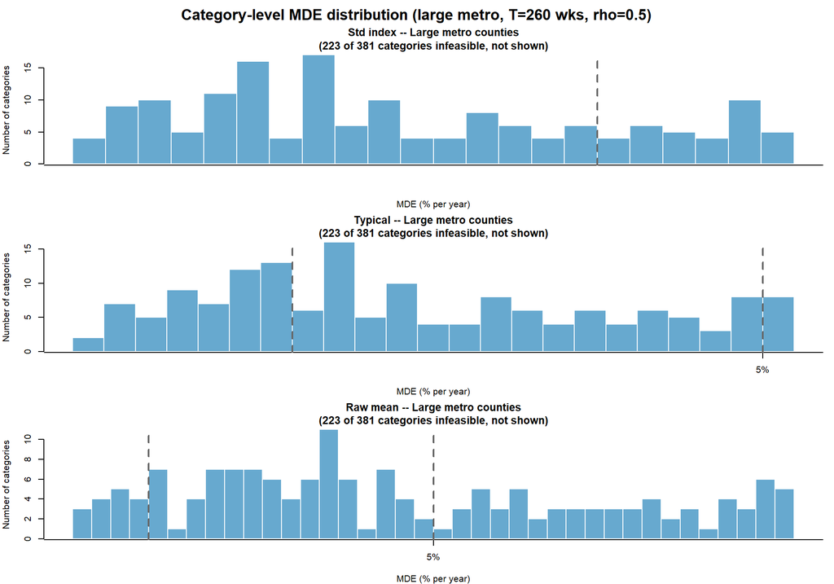

### 5.4.3 Which supercategories can support category-level analysis?

The table below shows, for each supercategory, how many of its constituent categories are viable (MDE < 10%/yr) at each county tier.

#### 5.4.3.1 Std index (sigma_txn = 0.15)

Viable categories per supercategory (MDE<10%, T=260 wks, rho=0.5): Std index

| Supercategory | Large metro (0.5%) | Mid-size (0.1%) | Small/rural (0.02%) |
| --- | --- | --- | --- |
| VEGETABLES | 21/35 | 13/35 | 1/35 |
| BEVERAGES | 12/18 | 8/18 | 2/18 |
| PREPARED FOODS | 19/36 | 9/36 | 0/36 |
| FRUIT | 24/50 | 5/50 | 0/50 |
| SALTY SNACKS | 14/18 | 6/18 | 1/18 |
| CHEESE | 18/58 | 6/58 | 0/58 |
| DESSERTS/SWEET GOODS | 11/49 | 2/49 | 1/49 |
| MILK PRODUCTS | 3/7 | 2/7 | 1/7 |
| COOKIES & CRACKERS | 2/4 | 2/4 | 2/4 |
| BREAD | 4/14 | 1/14 | 1/14 |
| COFFEE | 2/2 | 2/2 | 0/2 |
| PASTA/RICE/GRAINS | 4/7 | 2/7 | 0/7 |
| CEREAL & GRANOLA | 2/5 | 2/5 | 0/5 |
| EGGS | 1/4 | 1/4 | 1/4 |
| CONDIMENTS | 8/15 | 1/15 | 0/15 |
| SEAFOOD | 5/29 | 1/29 | 0/29 |
| WRAPS & TORTILLA SHELLS | 2/10 | 1/10 | 0/10 |
| NUT BUTTERS/JAM/JELLIES | 2/14 | 1/14 | 0/14 |
| PIZZA | 1/3 | 1/3 | 0/3 |
| MEAL COMBOS | 3/3 | 0/3 | 0/3 |

#### 5.4.3.2 Typical (sigma_txn = 0.3)

Viable categories per supercategory (MDE<10%, T=260 wks, rho=0.5): Typical

| Supercategory | Large metro (0.5%) | Mid-size (0.1%) | Small/rural (0.02%) |
| --- | --- | --- | --- |
| VEGETABLES | 21/35 | 13/35 | 1/35 |
| BEVERAGES | 12/18 | 8/18 | 2/18 |
| PREPARED FOODS | 19/36 | 9/36 | 0/36 |
| FRUIT | 24/50 | 5/50 | 0/50 |
| SALTY SNACKS | 14/18 | 6/18 | 1/18 |
| CHEESE | 18/58 | 6/58 | 0/58 |
| DESSERTS/SWEET GOODS | 11/49 | 2/49 | 1/49 |
| MILK PRODUCTS | 3/7 | 2/7 | 1/7 |
| COOKIES & CRACKERS | 2/4 | 2/4 | 2/4 |
| BREAD | 4/14 | 1/14 | 1/14 |
| COFFEE | 2/2 | 2/2 | 0/2 |
| PASTA/RICE/GRAINS | 4/7 | 2/7 | 0/7 |
| CEREAL & GRANOLA | 2/5 | 2/5 | 0/5 |
| EGGS | 1/4 | 1/4 | 1/4 |
| CONDIMENTS | 8/15 | 1/15 | 0/15 |
| SEAFOOD | 5/29 | 1/29 | 0/29 |
| WRAPS & TORTILLA SHELLS | 2/10 | 1/10 | 0/10 |
| NUT BUTTERS/JAM/JELLIES | 2/14 | 1/14 | 0/14 |
| PIZZA | 1/3 | 1/3 | 0/3 |
| MEAL COMBOS | 3/3 | 0/3 | 0/3 |

#### 5.4.3.3 Raw mean (sigma_txn = 0.5)

Viable categories per supercategory (MDE<10%, T=260 wks, rho=0.5): Raw mean

| Supercategory | Large metro (0.5%) | Mid-size (0.1%) | Small/rural (0.02%) |
| --- | --- | --- | --- |
| VEGETABLES | 21/35 | 13/35 | 1/35 |
| BEVERAGES | 12/18 | 8/18 | 2/18 |
| PREPARED FOODS | 19/36 | 9/36 | 0/36 |
| FRUIT | 24/50 | 5/50 | 0/50 |
| SALTY SNACKS | 14/18 | 6/18 | 1/18 |
| CHEESE | 18/58 | 6/58 | 0/58 |
| DESSERTS/SWEET GOODS | 11/49 | 2/49 | 1/49 |
| MILK PRODUCTS | 3/7 | 2/7 | 1/7 |
| COOKIES & CRACKERS | 2/4 | 2/4 | 2/4 |
| BREAD | 4/14 | 1/14 | 1/14 |
| COFFEE | 2/2 | 2/2 | 0/2 |
| PASTA/RICE/GRAINS | 4/7 | 2/7 | 0/7 |
| CEREAL & GRANOLA | 2/5 | 2/5 | 0/5 |
| EGGS | 1/4 | 1/4 | 1/4 |
| CONDIMENTS | 8/15 | 1/15 | 0/15 |
| SEAFOOD | 5/29 | 1/29 | 0/29 |
| WRAPS & TORTILLA SHELLS | 2/10 | 1/10 | 0/10 |
| NUT BUTTERS/JAM/JELLIES | 2/14 | 1/14 | 0/14 |
| PIZZA | 1/3 | 1/3 | 0/3 |
| MEAL COMBOS | 3/3 | 0/3 | 0/3 |

### 5.4.4 Top viable categories in mid-size counties

The following table lists categories that achieve MDE < 10%/yr in a mid-size county (0.1% of national panel), across all three variance scenarios. These are the categories where county-level trend analysis is most realistic.

#### 5.4.4.1 Std index (sigma_txn = 0.15)

Categories viable in mid-size counties (MDE<10%, T=260 wks, rho=0.5): Std index

| Supercategory | Category | Natl Occ | Large metro (0.5%) | Mid-size (0.1%) | Small/rural (0.02%) |
| --- | --- | --- | --- | --- | --- |
| BEVERAGES | SOFT DRINKS | 769,727 | 0.4% well_powered | 0.9% well_powered | 1.9% well_powered |
| MILK PRODUCTS | COWS MILK | 757,493 | 0.4% well_powered | 0.9% well_powered | 1.9% well_powered |
| BREAD | BREAD | 640,270 | 0.5% well_powered | 0.9% well_powered | 2.1% adequate |
| DESSERTS/SWEET GOODS | FROZEN NOVELTY & ICE CREAM | 530,385 | 0.5% well_powered | 1.0% well_powered | 2.3% adequate |
| COOKIES & CRACKERS | COOKIES (COOKIES & CRACKERS) | 508,971 | 0.5% well_powered | 1.0% well_powered | 2.3% adequate |
| BEVERAGES | FRUIT/VEG JUICE & DRINK | 507,400 | 0.5% well_powered | 1.0% well_powered | 2.3% adequate |
| EGGS | CHICKEN EGGS | 472,287 | 0.5% well_powered | 1.1% well_powered | 2.4% adequate |
| VEGETABLES | POTATOES | 466,819 | 0.5% well_powered | 1.1% well_powered | 2.4% adequate |
| SALTY SNACKS | POTATO CHIP | 448,088 | 0.5% well_powered | 1.1% well_powered | 2.5% adequate |
| COOKIES & CRACKERS | CRACKERS | 420,051 | 0.5% well_powered | 1.1% well_powered | 2.5% adequate |
| VEGETABLES | PRE PACKAGED SALADS | 415,124 | 0.5% well_powered | 1.2% well_powered | INFEASIBLE |
| CEREAL & GRANOLA | RTE CEREAL | 390,476 | 0.6% well_powered | 1.2% well_powered | INFEASIBLE |
| PREPARED FOODS | SOUP/STEW/BROTH/BOUILLON | 348,986 | 0.6% well_powered | 1.3% well_powered | INFEASIBLE |
| BEVERAGES | WATER | 328,667 | 0.6% well_powered | 1.3% well_powered | INFEASIBLE |
| COFFEE | RTD & PACKAGED COFFEE | 302,892 | 0.6% well_powered | 1.3% well_powered | INFEASIBLE |
| PREPARED FOODS | COMPLETE MEAL & MAIN COURSE | 301,491 | 0.6% well_powered | 1.3% well_powered | INFEASIBLE |
| CHEESE | CHEDDAR | 291,078 | 0.6% well_powered | 1.4% well_powered | INFEASIBLE |
| PASTA/RICE/GRAINS | PASTA (PASTA/RICE/GRAINS) | 282,257 | 0.6% well_powered | 1.4% well_powered | INFEASIBLE |
| SALTY SNACKS | TORTILLA CHIP | 268,536 | 0.7% well_powered | 1.4% well_powered | INFEASIBLE |
| COFFEE | COFFEE CREAMER | 264,274 | 0.7% well_powered | 1.4% well_powered | INFEASIBLE |
| VEGETABLES | TOMATOES | 261,306 | 0.7% well_powered | 1.4% well_powered | INFEASIBLE |
| FRUIT | STRAWBERRIES | 256,325 | 0.7% well_powered | 1.5% well_powered | INFEASIBLE |
| BEVERAGES | TEA | 255,997 | 0.7% well_powered | 1.5% well_powered | INFEASIBLE |
| PIZZA | PIZZA | 213,274 | 0.7% well_powered | 1.6% well_powered | INFEASIBLE |
| VEGETABLES | CARROTS | 191,623 | 0.8% well_powered | 1.7% well_powered | INFEASIBLE |
| WRAPS & TORTILLA SHELLS | SOFT SHELL TORTILLA | 190,920 | 0.8% well_powered | 1.7% well_powered | INFEASIBLE |
| FRUIT | BLUEBERRIES | 188,062 | 0.8% well_powered | 1.7% well_powered | INFEASIBLE |
| CHEESE | MOZZARELLA | 179,446 | 0.8% well_powered | 1.7% well_powered | INFEASIBLE |
| SALTY SNACKS | POPCORN | 178,025 | 0.8% well_powered | 1.7% well_powered | INFEASIBLE |
| VEGETABLES | LETTUCE | 172,728 | 0.8% well_powered | 1.8% well_powered | INFEASIBLE |
| PREPARED FOODS | SIDES | 161,167 | 0.8% well_powered | 1.8% well_powered | INFEASIBLE |
| BEVERAGES | ENERGY BEVERAGES | 159,186 | 0.8% well_powered | 1.8% well_powered | INFEASIBLE |
| DESSERTS/SWEET GOODS | CAKE | 159,007 | 0.8% well_powered | 1.8% well_powered | INFEASIBLE |
| PREPARED FOODS | APPETIZER | 157,078 | 0.8% well_powered | 1.9% well_powered | INFEASIBLE |
| CHEESE | CREAM CHEESE | 154,236 | 0.9% well_powered | 1.9% well_powered | INFEASIBLE |
| CHEESE | COTTAGE CHEESE | 148,466 | 0.9% well_powered | 1.9% well_powered | INFEASIBLE |
| BEVERAGES | SPARKLING WATER | 148,347 | 0.9% well_powered | 1.9% well_powered | INFEASIBLE |
| VEGETABLES | MIXED VEGETABLES | 144,292 | 0.9% well_powered | 1.9% well_powered | INFEASIBLE |
| PREPARED FOODS | MAC & CHEESE | 143,095 | 0.9% well_powered | 1.9% well_powered | INFEASIBLE |
| BEVERAGES | SPORT DRINKS | 137,705 | 0.9% well_powered | 2.0% well_powered | INFEASIBLE |
| VEGETABLES | MUSHROOMS | 135,369 | 0.9% well_powered | 2.0% adequate | INFEASIBLE |
| VEGETABLES | ONIONS | 134,393 | 0.9% well_powered | 2.0% adequate | INFEASIBLE |
| PREPARED FOODS | SALADS | 129,437 | 0.9% well_powered | 2.0% adequate | INFEASIBLE |
| VEGETABLES | PEPPERS | 127,004 | 0.9% well_powered | 2.1% adequate | INFEASIBLE |
| NUT BUTTERS/JAM/JELLIES | PEANUT BUTTER | 126,527 | 0.9% well_powered | 2.1% adequate | INFEASIBLE |
| VEGETABLES | CORN | 125,452 | 0.9% well_powered | 2.1% adequate | INFEASIBLE |
| SALTY SNACKS | PRETZEL | 124,635 | 0.9% well_powered | 2.1% adequate | INFEASIBLE |
| FRUIT | GRAPES | 122,088 | 1.0% well_powered | 2.1% adequate | INFEASIBLE |
| VEGETABLES | GREEN BEANS | 121,945 | 1.0% well_powered | 2.1% adequate | INFEASIBLE |
| FRUIT | APPLES | 115,917 | 1.0% well_powered | 2.2% adequate | INFEASIBLE |
| SALTY SNACKS | SNACK MIXES | 113,798 | 1.0% well_powered | 2.2% adequate | INFEASIBLE |
| FRUIT | MANDARINS | 113,564 | 1.0% well_powered | 2.2% adequate | INFEASIBLE |
| PASTA/RICE/GRAINS | NON INSTANT RICE | 113,284 | 1.0% well_powered | 2.2% adequate | INFEASIBLE |
| SALTY SNACKS | CHEESE SNACKS | 112,129 | 1.0% well_powered | 2.2% adequate | INFEASIBLE |
| CONDIMENTS | MAYONNAISE | 111,681 | 1.0% well_powered | 2.2% adequate | INFEASIBLE |
| SEAFOOD | TUNA | 103,275 | 1.0% well_powered | 2.3% adequate | INFEASIBLE |
| PREPARED FOODS | BREAKFAST MEALS & SANDWICHES | 101,862 | 1.0% well_powered | 2.3% adequate | INFEASIBLE |
| PREPARED FOODS | SANDWICHES | 100,776 | 1.0% well_powered | 2.3% adequate | INFEASIBLE |
| MILK PRODUCTS | LACTOSE REDUCED/FREE MILK | 94,159 | 1.1% well_powered | 2.4% adequate | INFEASIBLE |
| VEGETABLES | BROCCOLI | 90,922 | 1.1% well_powered | 2.4% adequate | INFEASIBLE |
| CHEESE | REMAINING CHEESE | 89,843 | 1.1% well_powered | 2.5% adequate | INFEASIBLE |
| BEVERAGES | VALUE ADD WATER | 89,395 | 1.1% well_powered | 2.5% adequate | INFEASIBLE |
| PREPARED FOODS | RAMEN | 88,897 | 1.1% well_powered | 2.5% adequate | INFEASIBLE |
| CHEESE | MEXICAN BLENDS | 86,698 | 1.1% well_powered | 2.5% adequate | INFEASIBLE |
| CEREAL & GRANOLA | HOT CEREAL | 86,435 | 1.1% well_powered | 2.5% adequate | INFEASIBLE |
| VEGETABLES | CUCUMBERS | 83,329 | 1.1% well_powered | 2.6% adequate | INFEASIBLE |

#### 5.4.4.2 Typical (sigma_txn = 0.3)

Categories viable in mid-size counties (MDE<10%, T=260 wks, rho=0.5): Typical

| Supercategory | Category | Natl Occ | Large metro (0.5%) | Mid-size (0.1%) | Small/rural (0.02%) |
| --- | --- | --- | --- | --- | --- |
| BEVERAGES | SOFT DRINKS | 769,727 | 0.8% well_powered | 1.7% well_powered | 3.8% adequate |
| MILK PRODUCTS | COWS MILK | 757,493 | 0.8% well_powered | 1.7% well_powered | 3.8% adequate |
| BREAD | BREAD | 640,270 | 0.8% well_powered | 1.8% well_powered | 4.1% adequate |
| DESSERTS/SWEET GOODS | FROZEN NOVELTY & ICE CREAM | 530,385 | 0.9% well_powered | 2.0% adequate | 4.6% adequate |
| COOKIES & CRACKERS | COOKIES (COOKIES & CRACKERS) | 508,971 | 0.9% well_powered | 2.1% adequate | 4.7% adequate |
| BEVERAGES | FRUIT/VEG JUICE & DRINK | 507,400 | 0.9% well_powered | 2.1% adequate | 4.7% adequate |
| EGGS | CHICKEN EGGS | 472,287 | 1.0% well_powered | 2.1% adequate | 4.8% adequate |
| VEGETABLES | POTATOES | 466,819 | 1.0% well_powered | 2.2% adequate | 4.9% adequate |
| SALTY SNACKS | POTATO CHIP | 448,088 | 1.0% well_powered | 2.2% adequate | 5.0% adequate |
| COOKIES & CRACKERS | CRACKERS | 420,051 | 1.0% well_powered | 2.3% adequate | 5.1% marginal |
| VEGETABLES | PRE PACKAGED SALADS | 415,124 | 1.0% well_powered | 2.3% adequate | INFEASIBLE |
| CEREAL & GRANOLA | RTE CEREAL | 390,476 | 1.1% well_powered | 2.4% adequate | INFEASIBLE |
| PREPARED FOODS | SOUP/STEW/BROTH/BOUILLON | 348,986 | 1.1% well_powered | 2.5% adequate | INFEASIBLE |
| BEVERAGES | WATER | 328,667 | 1.2% well_powered | 2.6% adequate | INFEASIBLE |
| COFFEE | RTD & PACKAGED COFFEE | 302,892 | 1.2% well_powered | 2.7% adequate | INFEASIBLE |
| PREPARED FOODS | COMPLETE MEAL & MAIN COURSE | 301,491 | 1.2% well_powered | 2.7% adequate | INFEASIBLE |
| CHEESE | CHEDDAR | 291,078 | 1.2% well_powered | 2.7% adequate | INFEASIBLE |
| PASTA/RICE/GRAINS | PASTA (PASTA/RICE/GRAINS) | 282,257 | 1.2% well_powered | 2.8% adequate | INFEASIBLE |
| SALTY SNACKS | TORTILLA CHIP | 268,536 | 1.3% well_powered | 2.8% adequate | INFEASIBLE |
| COFFEE | COFFEE CREAMER | 264,274 | 1.3% well_powered | 2.9% adequate | INFEASIBLE |
| VEGETABLES | TOMATOES | 261,306 | 1.3% well_powered | 2.9% adequate | INFEASIBLE |
| FRUIT | STRAWBERRIES | 256,325 | 1.3% well_powered | 2.9% adequate | INFEASIBLE |
| BEVERAGES | TEA | 255,997 | 1.3% well_powered | 2.9% adequate | INFEASIBLE |
| PIZZA | PIZZA | 213,274 | 1.4% well_powered | 3.2% adequate | INFEASIBLE |
| VEGETABLES | CARROTS | 191,623 | 1.5% well_powered | 3.4% adequate | INFEASIBLE |
| WRAPS & TORTILLA SHELLS | SOFT SHELL TORTILLA | 190,920 | 1.5% well_powered | 3.4% adequate | INFEASIBLE |
| FRUIT | BLUEBERRIES | 188,062 | 1.5% well_powered | 3.4% adequate | INFEASIBLE |
| CHEESE | MOZZARELLA | 179,446 | 1.6% well_powered | 3.5% adequate | INFEASIBLE |
| SALTY SNACKS | POPCORN | 178,025 | 1.6% well_powered | 3.5% adequate | INFEASIBLE |
| VEGETABLES | LETTUCE | 172,728 | 1.6% well_powered | 3.6% adequate | INFEASIBLE |
| PREPARED FOODS | SIDES | 161,167 | 1.6% well_powered | 3.7% adequate | INFEASIBLE |
| BEVERAGES | ENERGY BEVERAGES | 159,186 | 1.7% well_powered | 3.7% adequate | INFEASIBLE |
| DESSERTS/SWEET GOODS | CAKE | 159,007 | 1.7% well_powered | 3.7% adequate | INFEASIBLE |
| PREPARED FOODS | APPETIZER | 157,078 | 1.7% well_powered | 3.7% adequate | INFEASIBLE |
| CHEESE | CREAM CHEESE | 154,236 | 1.7% well_powered | 3.8% adequate | INFEASIBLE |
| CHEESE | COTTAGE CHEESE | 148,466 | 1.7% well_powered | 3.8% adequate | INFEASIBLE |
| BEVERAGES | SPARKLING WATER | 148,347 | 1.7% well_powered | 3.8% adequate | INFEASIBLE |
| VEGETABLES | MIXED VEGETABLES | 144,292 | 1.7% well_powered | 3.9% adequate | INFEASIBLE |
| PREPARED FOODS | MAC & CHEESE | 143,095 | 1.7% well_powered | 3.9% adequate | INFEASIBLE |
| BEVERAGES | SPORT DRINKS | 137,705 | 1.8% well_powered | 4.0% adequate | INFEASIBLE |
| VEGETABLES | MUSHROOMS | 135,369 | 1.8% well_powered | 4.0% adequate | INFEASIBLE |
| VEGETABLES | ONIONS | 134,393 | 1.8% well_powered | 4.0% adequate | INFEASIBLE |
| PREPARED FOODS | SALADS | 129,437 | 1.8% well_powered | 4.1% adequate | INFEASIBLE |
| VEGETABLES | PEPPERS | 127,004 | 1.8% well_powered | 4.2% adequate | INFEASIBLE |
| NUT BUTTERS/JAM/JELLIES | PEANUT BUTTER | 126,527 | 1.9% well_powered | 4.2% adequate | INFEASIBLE |
| VEGETABLES | CORN | 125,452 | 1.9% well_powered | 4.2% adequate | INFEASIBLE |
| SALTY SNACKS | PRETZEL | 124,635 | 1.9% well_powered | 4.2% adequate | INFEASIBLE |
| FRUIT | GRAPES | 122,088 | 1.9% well_powered | 4.2% adequate | INFEASIBLE |
| VEGETABLES | GREEN BEANS | 121,945 | 1.9% well_powered | 4.2% adequate | INFEASIBLE |
| FRUIT | APPLES | 115,917 | 1.9% well_powered | 4.4% adequate | INFEASIBLE |
| SALTY SNACKS | SNACK MIXES | 113,798 | 2.0% well_powered | 4.4% adequate | INFEASIBLE |
| FRUIT | MANDARINS | 113,564 | 2.0% well_powered | 4.4% adequate | INFEASIBLE |
| PASTA/RICE/GRAINS | NON INSTANT RICE | 113,284 | 2.0% well_powered | 4.4% adequate | INFEASIBLE |
| SALTY SNACKS | CHEESE SNACKS | 112,129 | 2.0% well_powered | 4.4% adequate | INFEASIBLE |
| CONDIMENTS | MAYONNAISE | 111,681 | 2.0% well_powered | 4.4% adequate | INFEASIBLE |
| SEAFOOD | TUNA | 103,275 | 2.0% adequate | 4.6% adequate | INFEASIBLE |
| PREPARED FOODS | BREAKFAST MEALS & SANDWICHES | 101,862 | 2.1% adequate | 4.7% adequate | INFEASIBLE |
| PREPARED FOODS | SANDWICHES | 100,776 | 2.1% adequate | 4.7% adequate | INFEASIBLE |
| MILK PRODUCTS | LACTOSE REDUCED/FREE MILK | 94,159 | 2.1% adequate | 4.8% adequate | INFEASIBLE |
| VEGETABLES | BROCCOLI | 90,922 | 2.2% adequate | 4.9% adequate | INFEASIBLE |
| CHEESE | REMAINING CHEESE | 89,843 | 2.2% adequate | 5.0% adequate | INFEASIBLE |
| BEVERAGES | VALUE ADD WATER | 89,395 | 2.2% adequate | 5.0% adequate | INFEASIBLE |
| PREPARED FOODS | RAMEN | 88,897 | 2.2% adequate | 5.0% adequate | INFEASIBLE |
| CHEESE | MEXICAN BLENDS | 86,698 | 2.2% adequate | 5.1% marginal | INFEASIBLE |
| CEREAL & GRANOLA | HOT CEREAL | 86,435 | 2.2% adequate | 5.1% marginal | INFEASIBLE |
| VEGETABLES | CUCUMBERS | 83,329 | 2.3% adequate | 5.2% marginal | INFEASIBLE |

#### 5.4.4.3 Raw mean (sigma_txn = 0.5)

Categories viable in mid-size counties (MDE<10%, T=260 wks, rho=0.5): Raw mean

| Supercategory | Category | Natl Occ | Large metro (0.5%) | Mid-size (0.1%) | Small/rural (0.02%) |
| --- | --- | --- | --- | --- | --- |
| BEVERAGES | SOFT DRINKS | 769,727 | 1.3% well_powered | 2.8% adequate | 6.4% marginal |
| MILK PRODUCTS | COWS MILK | 757,493 | 1.3% well_powered | 2.8% adequate | 6.4% marginal |
| BREAD | BREAD | 640,270 | 1.4% well_powered | 3.1% adequate | 7.0% marginal |
| DESSERTS/SWEET GOODS | FROZEN NOVELTY & ICE CREAM | 530,385 | 1.5% well_powered | 3.4% adequate | 7.7% marginal |
| COOKIES & CRACKERS | COOKIES (COOKIES & CRACKERS) | 508,971 | 1.5% well_powered | 3.5% adequate | 7.9% marginal |
| BEVERAGES | FRUIT/VEG JUICE & DRINK | 507,400 | 1.5% well_powered | 3.5% adequate | 7.9% marginal |
| EGGS | CHICKEN EGGS | 472,287 | 1.6% well_powered | 3.6% adequate | 8.2% marginal |
| VEGETABLES | POTATOES | 466,819 | 1.6% well_powered | 3.6% adequate | 8.2% marginal |
| SALTY SNACKS | POTATO CHIP | 448,088 | 1.6% well_powered | 3.7% adequate | 8.4% marginal |
| COOKIES & CRACKERS | CRACKERS | 420,051 | 1.7% well_powered | 3.8% adequate | 8.7% marginal |
| VEGETABLES | PRE PACKAGED SALADS | 415,124 | 1.7% well_powered | 3.8% adequate | INFEASIBLE |
| CEREAL & GRANOLA | RTE CEREAL | 390,476 | 1.8% well_powered | 3.9% adequate | INFEASIBLE |
| PREPARED FOODS | SOUP/STEW/BROTH/BOUILLON | 348,986 | 1.9% well_powered | 4.2% adequate | INFEASIBLE |
| BEVERAGES | WATER | 328,667 | 1.9% well_powered | 4.3% adequate | INFEASIBLE |
| COFFEE | RTD & PACKAGED COFFEE | 302,892 | 2.0% well_powered | 4.5% adequate | INFEASIBLE |
| PREPARED FOODS | COMPLETE MEAL & MAIN COURSE | 301,491 | 2.0% well_powered | 4.5% adequate | INFEASIBLE |
| CHEESE | CHEDDAR | 291,078 | 2.0% adequate | 4.6% adequate | INFEASIBLE |
| PASTA/RICE/GRAINS | PASTA (PASTA/RICE/GRAINS) | 282,257 | 2.1% adequate | 4.7% adequate | INFEASIBLE |
| SALTY SNACKS | TORTILLA CHIP | 268,536 | 2.1% adequate | 4.8% adequate | INFEASIBLE |
| COFFEE | COFFEE CREAMER | 264,274 | 2.1% adequate | 4.8% adequate | INFEASIBLE |
| VEGETABLES | TOMATOES | 261,306 | 2.1% adequate | 4.8% adequate | INFEASIBLE |
| FRUIT | STRAWBERRIES | 256,325 | 2.2% adequate | 4.9% adequate | INFEASIBLE |
| BEVERAGES | TEA | 255,997 | 2.2% adequate | 4.9% adequate | INFEASIBLE |
| PIZZA | PIZZA | 213,274 | 2.4% adequate | 5.4% marginal | INFEASIBLE |
| VEGETABLES | CARROTS | 191,623 | 2.5% adequate | 5.7% marginal | INFEASIBLE |
| WRAPS & TORTILLA SHELLS | SOFT SHELL TORTILLA | 190,920 | 2.5% adequate | 5.7% marginal | INFEASIBLE |
| FRUIT | BLUEBERRIES | 188,062 | 2.5% adequate | 5.7% marginal | INFEASIBLE |
| CHEESE | MOZZARELLA | 179,446 | 2.6% adequate | 5.9% marginal | INFEASIBLE |
| SALTY SNACKS | POPCORN | 178,025 | 2.6% adequate | 5.9% marginal | INFEASIBLE |
| VEGETABLES | LETTUCE | 172,728 | 2.6% adequate | 6.0% marginal | INFEASIBLE |
| PREPARED FOODS | SIDES | 161,167 | 2.7% adequate | 6.2% marginal | INFEASIBLE |
| BEVERAGES | ENERGY BEVERAGES | 159,186 | 2.8% adequate | 6.2% marginal | INFEASIBLE |
| DESSERTS/SWEET GOODS | CAKE | 159,007 | 2.8% adequate | 6.3% marginal | INFEASIBLE |
| PREPARED FOODS | APPETIZER | 157,078 | 2.8% adequate | 6.3% marginal | INFEASIBLE |
| CHEESE | CREAM CHEESE | 154,236 | 2.8% adequate | 6.4% marginal | INFEASIBLE |
| CHEESE | COTTAGE CHEESE | 148,466 | 2.9% adequate | 6.5% marginal | INFEASIBLE |
| BEVERAGES | SPARKLING WATER | 148,347 | 2.9% adequate | 6.5% marginal | INFEASIBLE |
| VEGETABLES | MIXED VEGETABLES | 144,292 | 2.9% adequate | 6.6% marginal | INFEASIBLE |
| PREPARED FOODS | MAC & CHEESE | 143,095 | 2.9% adequate | 6.6% marginal | INFEASIBLE |
| BEVERAGES | SPORT DRINKS | 137,705 | 3.0% adequate | 6.7% marginal | INFEASIBLE |
| VEGETABLES | MUSHROOMS | 135,369 | 3.0% adequate | 6.8% marginal | INFEASIBLE |
| VEGETABLES | ONIONS | 134,393 | 3.0% adequate | 6.8% marginal | INFEASIBLE |
| PREPARED FOODS | SALADS | 129,437 | 3.1% adequate | 7.0% marginal | INFEASIBLE |
| VEGETABLES | PEPPERS | 127,004 | 3.1% adequate | 7.0% marginal | INFEASIBLE |
| NUT BUTTERS/JAM/JELLIES | PEANUT BUTTER | 126,527 | 3.1% adequate | 7.0% marginal | INFEASIBLE |
| VEGETABLES | CORN | 125,452 | 3.1% adequate | 7.1% marginal | INFEASIBLE |
| SALTY SNACKS | PRETZEL | 124,635 | 3.1% adequate | 7.1% marginal | INFEASIBLE |
| FRUIT | GRAPES | 122,088 | 3.1% adequate | 7.2% marginal | INFEASIBLE |
| VEGETABLES | GREEN BEANS | 121,945 | 3.2% adequate | 7.2% marginal | INFEASIBLE |
| FRUIT | APPLES | 115,917 | 3.2% adequate | 7.4% marginal | INFEASIBLE |
| SALTY SNACKS | SNACK MIXES | 113,798 | 3.3% adequate | 7.4% marginal | INFEASIBLE |
| FRUIT | MANDARINS | 113,564 | 3.3% adequate | 7.4% marginal | INFEASIBLE |
| PASTA/RICE/GRAINS | NON INSTANT RICE | 113,284 | 3.3% adequate | 7.4% marginal | INFEASIBLE |
| SALTY SNACKS | CHEESE SNACKS | 112,129 | 3.3% adequate | 7.5% marginal | INFEASIBLE |
| CONDIMENTS | MAYONNAISE | 111,681 | 3.3% adequate | 7.5% marginal | INFEASIBLE |
| SEAFOOD | TUNA | 103,275 | 3.4% adequate | 7.8% marginal | INFEASIBLE |
| PREPARED FOODS | BREAKFAST MEALS & SANDWICHES | 101,862 | 3.5% adequate | 7.9% marginal | INFEASIBLE |
| PREPARED FOODS | SANDWICHES | 100,776 | 3.5% adequate | 7.9% marginal | INFEASIBLE |
| MILK PRODUCTS | LACTOSE REDUCED/FREE MILK | 94,159 | 3.6% adequate | 8.2% marginal | INFEASIBLE |
| VEGETABLES | BROCCOLI | 90,922 | 3.7% adequate | 8.3% marginal | INFEASIBLE |
| CHEESE | REMAINING CHEESE | 89,843 | 3.7% adequate | 8.4% marginal | INFEASIBLE |
| BEVERAGES | VALUE ADD WATER | 89,395 | 3.7% adequate | 8.4% marginal | INFEASIBLE |
| PREPARED FOODS | RAMEN | 88,897 | 3.7% adequate | 8.4% marginal | INFEASIBLE |
| CHEESE | MEXICAN BLENDS | 86,698 | 3.7% adequate | 8.6% marginal | INFEASIBLE |
| CEREAL & GRANOLA | HOT CEREAL | 86,435 | 3.8% adequate | 8.6% marginal | INFEASIBLE |
| VEGETABLES | CUCUMBERS | 83,329 | 3.8% adequate | 8.7% marginal | INFEASIBLE |